# Computational Probability & Monte Carlo Simulations

Robert Kohn

Fall 2025

# 1 Introduction & Mathematical Framework

Monte Carlo simulation provides a computational bridge between theoretical mathematical statistics and empirical probability. As a Mathematics and Statistics double major, this project investigates how computational algorithms verify theoretical expectations, asymptotic variance convergence, joint bivariate distributions, and multi-dimensional integration.

# 2 Part 1: Discrete Distributions & Law of Large Numbers

## 2.1 Binomial Distribution Moment Convergence

Consider a sequence of $n = 100$ independent Bernoulli trials with success probability $p = 0.30$:
$$X
\sim \text{Binomial}(n = 100, p = 0.30)$$

Theoretical moments:
$$E[X] = np = 100
\times 0.30 = 30$$
$$\text{Var}(X) =
np(1 - p) = 100 \times 0.30 \times 0.70 = 21.00$$

```r
n_draws <- 100000
n_trials <- 100
p_binom <- 0.3

binom_sim <- rbinom(n_draws, size = n_trials, prob = p_binom)
binom_var_mc <- var(binom_sim)
binom_var_th <- n_trials * p_binom * (1 - p_binom)

cat(sprintf("Monte Carlo Variance: %.4f | Theoretical: %.4f | Absolute Error: %.6f\n",
            binom_var_mc, binom_var_th, abs(binom_var_mc - binom_var_th)))
```

```
## Monte Carlo Variance: 21.0478 | Theoretical: 21.0000 | Absolute Error: 0.047750
```

The running sample variance demonstrates asymptotic convergence toward the theoretical variance of 21.0:

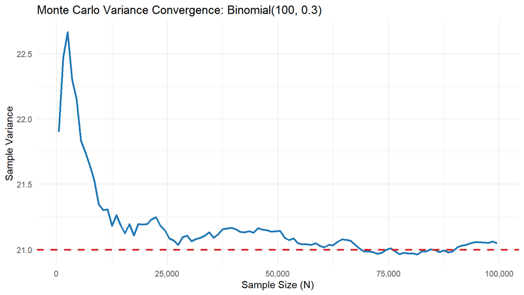

## 2.2 Linear Combinations of Independent Discrete Variables

Let $X \sim \text{Poisson}(\lambda = 2)$ and $Y \sim \text{Geometric}(p = 0.50)$ (number of failures before first success). By linearity of expectation:
$$E[X + Y] = E[X] + E[Y] =
\lambda + \frac{1 - p}{p} = 2 + \frac{0.50}{0.50} = 3.00$$

```r
x_sim <- rpois(n_draws, lambda = 2)
y_sim <- rgeom(n_draws, prob = 0.5)
sum_sim <- x_sim + y_sim

cat(sprintf("Monte Carlo E[X + Y]: %.4f | Theoretical: %.4f | Error: %.6f\n",
            mean(sum_sim), 3.0, abs(mean(sum_sim) - 3.0)))
```

```
## Monte Carlo E[X + Y]: 2.9965 | Theoretical: 3.0000 | Error: 0.003530
```

## 2.3 Negative Binomial Tail Probabilities

For $X \sim \text{NegBin}(r = 5, p = 0.65)$, we calculate the tail probability $P(X > 6)$:
$$P(X > 6) = 1 - \sum_{k=0}^6 \binom{k + r -
1}{k} (1 - p)^k p^r$$

```r
nb_sim <- rnbinom(n_draws, size = 5, prob = 0.65)
p_gt_6_mc <- mean(nb_sim > 6)
p_gt_6_th <- 1 - sum(sapply(0:6, function(k) choose(k + 5 - 1, k) * (1 - 0.65)^k * (0.65)^5))

cat(sprintf("Monte Carlo P(X > 6): %.5f | Theoretical: %.5f | Error: %.6f\n",
            p_gt_6_mc, p_gt_6_th, abs(p_gt_6_mc - p_gt_6_th)))
```

```
## Monte Carlo P(X > 6): 0.04924 | Theoretical: 0.05014 | Error: 0.000903
```

# 3 Part 2: Continuous Distributions & Monte Carlo Integration

Simulating across continuous parametric families: Uniform $\mathcal{U}(3, 10)$, Exponential $\text{Exp}(\lambda = 2)$, Chi-squared $\chi^2(5)$, and Beta $\text{Beta}(2, 4)$:

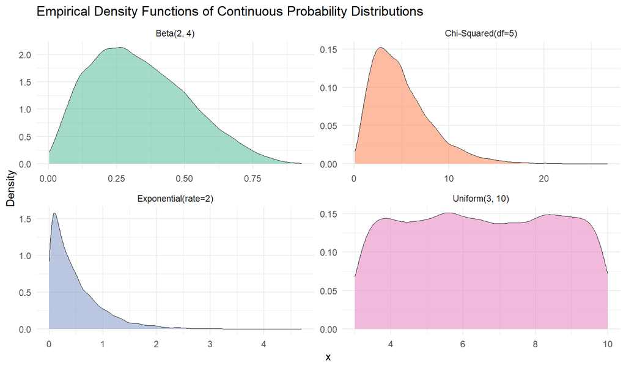

```r
unif_draws  <- runif(10000, min = 3, max = 10)
exp_draws   <- rexp(10000, rate = 2)
chisq_draws <- rchisq(10000, df = 5)
beta_draws  <- rbeta(10000, shape1 = 2, shape2 = 4)

dist_df <- data.frame(
  Value = c(unif_draws, exp_draws, chisq_draws, beta_draws),
  Distribution = factor(rep(c("Uniform(3, 10)", "Exponential(rate=2)", "Chi-Squared(df=5)", "Beta(2, 4)"),
                            each = 10000))
)

ggplot(dist_df, aes(x = Value, fill = Distribution)) +
  geom_density(alpha = 0.6, color = "black", linewidth = 0.3) +
  facet_wrap(~ Distribution, scales = "free", nrow = 2) +
  scale_fill_brewer(palette = "Set2") +
  labs(title = "Empirical Density Functions of Continuous Probability Distributions", x = "x", y = "Density") +
  theme_minimal() +
  theme(legend.position = "none")
```

# 4 Part 3: Bivariate Normal Distribution & Hypothesis Testing

Let $\mathbf{X} = (X_1, X_2)^T \sim \mathcal{N}_2(\boldsymbol{0}, \mathbf{I}_2)$. Under independence, the joint density factors:
$$f(x_1, x_2) = f_{X_1}(x_1)
f_{X_2}(x_2)$$

```r
mu_vec <- c(0, 0)
cov_mat <- diag(2)

joint_origin <- dmnorm(c(0, 0), mean = mu_vec, varcov = cov_mat)
prod_marg    <- dnorm(0) * dnorm(0)
cat(sprintf("Joint PDF at (0, 0): %.6f | Product of Marginals: %.6f\n", joint_origin, prod_marg))
```

```
## Joint PDF at (0, 0): 0.159155 | Product of Marginals: 0.159155
```

```r
# Cumulative probability over rectangular region [-2, 2] x [-2, 2]
p_rect_joint <- pmnorm(c(2, 2), mean = mu_vec, varcov = cov_mat) -
                pmnorm(c(-2, 2), mean = mu_vec, varcov = cov_mat) -
                pmnorm(c(2, -2), mean = mu_vec, varcov = cov_mat) +
                pmnorm(c(-2, -2), mean = mu_vec, varcov = cov_mat)
p_rect_marg  <- (pnorm(2) - pnorm(-2))^2
cat(sprintf("Joint CDF Rectangle: %.6f | Marginal Product: %.6f\n", p_rect_joint, p_rect_marg))
```

```
## Joint CDF Rectangle: 0.911070 | Marginal Product: 0.911070
```

## 4.1 Sample Correlation & Hypothesis Testing

Simulating $N = 2,000$ points from standard bivariate normal:
$$H_0: \rho = 0
\quad \text{vs.} \quad H_1: \rho \neq 0$$

```r
biv_sim <- rmnorm(2000, mean = mu_vec, varcov = cov_mat)
cor_res <- cor.test(biv_sim[, 1], biv_sim[, 2])
cat(sprintf("Sample Pearson r: %.4f | p-value: %.4f | Decision: %s\n",
            cor_res$estimate, cor_res$p.value,
            ifelse(cor_res$p.value > 0.05, "Fail to reject H0 (Consistent with independence)", "Reject H0")))
```

```
## Sample Pearson r: -0.0123 | p-value: 0.5827 | Decision: Fail to reject H0 (Consistent with independence)
```

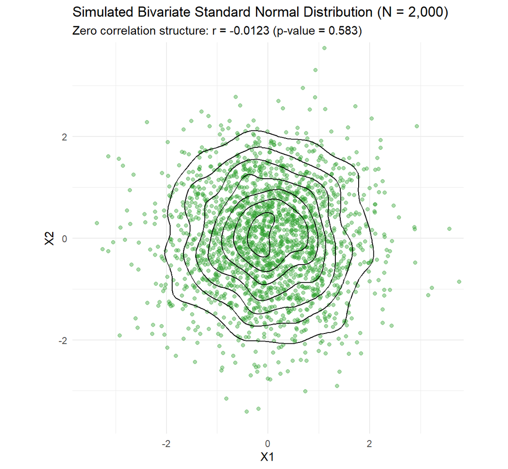

# 5 Part 4: Numerical Quadrature & Combinatorics

## 5.1 1D and Multidimensional Integration

Integrating $g(x) = x^2 + 3x - 4$ over $[0, 2]$:
$$\int_0^2 (x^2 + 3x - 4) dx = \left[ \frac{x^3}{3}
+ \frac{3x^2}{2} - 4x \right]_0^2 = \frac{8}{3} + 6 - 8 = \frac{2}{3}
\approx 0.666667$$

```r
quad_1d <- integrate(function(x) x^2 + 3*x - 4, lower = 0, upper = 2)
cat(sprintf("Numerical Quadrature: %.6f | True Value: 0.666667\n", quad_1d$value))
```

```
## Numerical Quadrature: 0.666667 | True Value: 0.666667
```

```r
# 2D Adaptive Integration over [0, 1] x [0, 1.5]
poly_2d <- function(vec) vec[1]^2 + 3*vec[1]*vec[2] - 4*vec[2]^3
quad_2d <- adaptIntegrate(poly_2d, lowerLimit = c(0, 0), upperLimit = c(1, 1.5))
cat(sprintf("2D Adaptive Quadrature: %.6f | Error estimate: %.2e\n", quad_2d$integral, quad_2d$error))
```

```
## 2D Adaptive Quadrature: -2.875000 | Error estimate: 0.00e+00
```

## 5.2 Combinatorics

Enumerating all subsets of size $k = 3$ chosen from $n = 8$ items without replacement:
$$\binom{8}{3} = \frac{8
\times 7 \times 6}{3 \times 2 \times 1} = 56$$

```r
flavors <- c("Vanilla", "Chocolate", "Strawberry", "Cookies & Cream",
             "Cookie Dough", "Mint Chip", "Butter Pecan", "Coffee")
combos <- CombSet(flavors, 3, repl = FALSE, ord = FALSE)
cat(sprintf("Empirical combinations generated: %d | choose(8, 3): %d\n", nrow(combos), choose(8, 3)))
```

```
## Empirical combinations generated: 56 | choose(8, 3): 56
```